# Learning Julia

This notebook is meant to be an introduction to the Julia Language. Below we will provide some examples of basic operations, functions, and data types. This tutorial was made by following the walkthrough at this [link](https://www.analyticsvidhya.com/blog/2017/10/comprehensive-tutorial-learn-data-science-julia-from-scratch/).

The full Julia documentation (Version 1) is available [here](https://docs.julialang.org/en/v1/).

## Operations

Addition

```julia
4+5
```

```
9
```

Exponentiation

```julia
3^4
```

```
81
```

Division

```julia
91/2
```

```
45.5
```

## Data Types

### Arrays

```julia
A = [10, 20, 30]
```

```
3-element Array{Int64,1}:
 10
 20
 30
```

Access the first element of the array

```julia
A[1] #Julia is a 1-indexed language
```

```
10
```

### Column Vectors

```julia
B = [10; 20; 30] # Semi-colon denotes row-change
```

```
3-element Array{Int64,1}:
 10
 20
 30
```

Change the value of the first entry

```julia
B[1] = 199
B
```

```
3-element Array{Int64,1}:
 199
  20
  30
```

### Matrix operations

Create an array

```julia
M = [1 2 3; 4 5 6; 7 8 9]
```

```
3×3 Array{Int64,2}:
 1  2  3
 4  5  6
 7  8  9
```

Access/change the elements of an array by index

```julia
M[1,2] = 3663
```

```
3663
```

Transpose a matrix with a single quote

```julia
M'
```

```
3×3 LinearAlgebra.Adjoint{Int64,Array{Int64,2}}:
    1  4  7
 3663  5  8
    3  6  9
```

Take the inverse of a matrix with the inv() command

```julia
inv(M)
```

```
3×3 Array{Float64,2}:
 -0.000136575  -1.49973       0.999863
  0.000273149  -0.000546299   0.000273149
 -0.000136575   1.16694      -0.666803
```

### Dictionaries

A dictionary is an unordered set of key:value pairs, with unique keys in each dictionary.

Create a dictionary with the Dict() function

```julia
D = Dict(
    "first_name" => "Zane",
    "last_name" => "Murphy"
)
```

```
Dict{String,String} with 2 entries:
  "first_name" => "Zane"
  "last_name"  => "Murphy"
```

Access the elements using keys

```julia
D["first_name"]
```

```
"Zane"
```

```julia
D["last_name"]
```

```
"Murphy"
```

Count the number of elements in a dictionary

```julia
D.count
```

```
2
```

### Strings

Strings can simply be defined by use of double ( ” ) or triple ( ”’ ) quotes. Like Python, strings in Julia are also immutable.

Create a string

```julia
text = "Sample String"
```

```
"Sample String"
```

Access a letter of a string

```julia
text[1]
```

```
'S': ASCII/Unicode U+0053 (category Lu: Letter, uppercase)
```

Get the length of a string

```julia
length(text)
```

```
13
```

Get a subset of a string

```julia
text[1:6]
```

```
"Sample"
```

Remember that strings are immutable

```julia
text[1] = "C"
```

```
MethodError: no method matching setindex!(::String, ::String, ::Int64)

Stacktrace:
 [1] top-level scope at In[114]:1
```

## Loops/Conditionals

### For Loop

The method for iteration in Julia has the following syntax:

for i in [Julia Iterable] expression(i) end

“Julia Iterable” can be a vector, string or other advanced data structure

Let's compute a factorial

```julia
num = 1

for i in range(1, stop=5)
    num = num*i
end

print(num)
```

```
120
```

Or we can do this using the ':' syntax as well

```julia
num = 1

for i in 1:5
    num = num*i
end

print(num)
```

```
120
```

### While Loop

Let's try factorial with a while loop

```julia
i = 5
total = 1

while i > 0
    total = total*i
    i = i-1
end

print(total)
```

```
120
```

### Conditionals

The following demonstrates the use of conditionals in Julia

```julia
for i in 1:10
    print(i)
    if i < 4
        print(" is less than four\n")
    elseif 4 <= i & i <= 7
        print(" is between four and seven\n")
    else
        print(" is greater than seven\n")
    end
end
```

```
1 is less than four
2 is less than four
3 is less than four
4 is between four and seven
5 is between four and seven
6 is between four and seven
7 is between four and seven
8 is greater than seven
9 is greater than seven
10 is greater than seven
```

## DataFrames

Now we can get into the good stuff: Dataframes and their manipulations.

Let's figure out what directory we are working in

```julia
pwd()
```

```
"/Users/zanemurphy/Documents/julia/julia_scripts/julia_test"
```

Now let's figure out where the data is stored

```julia
readdir()
```

```
6-element Array{String,1}:
 ".git"
 ".gitignore"
 ".ipynb_checkpoints"
 "data_files"
 "julia_test.html"
 "julia_test.ipynb"
```

```julia
readdir("data_files")
```

```
2-element Array{String,1}:
 "vidhya_loan_test.csv"
 "vidhya_loan_train.csv"
```

Read in the training and testing data to Julia dataframes

```julia
using CSV, DataFrames
```

```julia
train = CSV.read("data_files/vidhya_loan_train.csv", copycols=true)
test = CSV.read("data_files/vidhya_loan_test.csv", copycols=true)
```

|  | Loan_ID String | Gender String⍰ | Married String | Dependents String⍰ | Education String | Self_Employed String⍰ | ApplicantIncome Int64 |
| --- | --- | --- | --- | --- | --- | --- | --- |
| 1 | LP001015 | Male | Yes | 0 | Graduate | No | 5720 |
| 2 | LP001022 | Male | Yes | 1 | Graduate | No | 3076 |
| 3 | LP001031 | Male | Yes | 2 | Graduate | No | 5000 |
| 4 | LP001035 | Male | Yes | 2 | Graduate | No | 2340 |
| 5 | LP001051 | Male | No | 0 | Not Graduate | No | 3276 |
| 6 | LP001054 | Male | Yes | 0 | Not Graduate | Yes | 2165 |
| 7 | LP001055 | Female | No | 1 | Not Graduate | No | 2226 |
| 8 | LP001056 | Male | Yes | 2 | Not Graduate | No | 3881 |
| 9 | LP001059 | Male | Yes | 2 | Graduate | missing | 13633 |
| 10 | LP001067 | Male | No | 0 | Not Graduate | No | 2400 |
| 11 | LP001078 | Male | No | 0 | Not Graduate | No | 3091 |
| 12 | LP001082 | Male | Yes | 1 | Graduate | missing | 2185 |
| 13 | LP001083 | Male | No | 3+ | Graduate | No | 4166 |
| 14 | LP001094 | Male | Yes | 2 | Graduate | missing | 12173 |
| 15 | LP001096 | Female | No | 0 | Graduate | No | 4666 |
| 16 | LP001099 | Male | No | 1 | Graduate | No | 5667 |
| 17 | LP001105 | Male | Yes | 2 | Graduate | No | 4583 |
| 18 | LP001107 | Male | Yes | 3+ | Graduate | No | 3786 |
| 19 | LP001108 | Male | Yes | 0 | Graduate | No | 9226 |
| 20 | LP001115 | Male | No | 0 | Graduate | No | 1300 |
| 21 | LP001121 | Male | Yes | 1 | Not Graduate | No | 1888 |
| 22 | LP001124 | Female | No | 3+ | Not Graduate | No | 2083 |
| 23 | LP001128 | missing | No | 0 | Graduate | No | 3909 |
| 24 | LP001135 | Female | No | 0 | Not Graduate | No | 3765 |
| 25 | LP001149 | Male | Yes | 0 | Graduate | No | 5400 |
| 26 | LP001153 | Male | No | 0 | Graduate | No | 0 |
| 27 | LP001163 | Male | Yes | 2 | Graduate | No | 4363 |
| 28 | LP001169 | Male | Yes | 0 | Graduate | No | 7500 |
| 29 | LP001174 | Male | Yes | 0 | Graduate | No | 3772 |
| 30 | LP001176 | Male | No | 0 | Graduate | No | 2942 |
| ⋮ | ⋮ | ⋮ | ⋮ | ⋮ | ⋮ | ⋮ | ⋮ |

Issue some basic table commands on the training and testing set

```julia
size(train)
```

```
(614, 13)
```

```julia
size(test)
```

```
(367, 12)
```

```julia
names(test)
```

```
12-element Array{Symbol,1}:
 :Loan_ID
 :Gender
 :Married
 :Dependents
 :Education
 :Self_Employed
 :ApplicantIncome
 :CoapplicantIncome
 :LoanAmount
 :Loan_Amount_Term
 :Credit_History
 :Property_Area
```

```julia
first(train, 10)
```

|  | Loan_ID String | Gender String⍰ | Married String⍰ | Dependents String⍰ | Education String | Self_Employed String⍰ | ApplicantIncome Int64 |
| --- | --- | --- | --- | --- | --- | --- | --- |
| 1 | LP001002 | Male | No | 0 | Graduate | No | 5849 |
| 2 | LP001003 | Male | Yes | 1 | Graduate | No | 4583 |
| 3 | LP001005 | Male | Yes | 0 | Graduate | Yes | 3000 |
| 4 | LP001006 | Male | Yes | 0 | Not Graduate | No | 2583 |
| 5 | LP001008 | Male | No | 0 | Graduate | No | 6000 |
| 6 | LP001011 | Male | Yes | 2 | Graduate | Yes | 5417 |
| 7 | LP001013 | Male | Yes | 0 | Not Graduate | No | 2333 |
| 8 | LP001014 | Male | Yes | 3+ | Graduate | No | 3036 |
| 9 | LP001018 | Male | Yes | 2 | Graduate | No | 4006 |
| 10 | LP001020 | Male | Yes | 1 | Graduate | No | 12841 |

Summarize the data set with 'describe'

```julia
describe(train)
```

|  | variable Symbol | mean Union… | min Any | median Union… | max Any | nunique Union… | nmissing Union… |
| --- | --- | --- | --- | --- | --- | --- | --- |
| 1 | Loan_ID |  | LP001002 |  | LP002990 | 614 |  |
| 2 | Gender |  | Female |  | Male | 2 | 13 |
| 3 | Married |  | No |  | Yes | 2 | 3 |
| 4 | Dependents |  | 0 |  | 3+ | 4 | 15 |
| 5 | Education |  | Graduate |  | Not Graduate | 2 |  |
| 6 | Self_Employed |  | No |  | Yes | 2 | 32 |
| 7 | ApplicantIncome | 5403.46 | 150 | 3812.5 | 81000 |  |  |
| 8 | CoapplicantIncome | 1621.25 | 0.0 | 1188.5 | 41667.0 |  |  |
| 9 | LoanAmount | 146.412 | 9 | 128.0 | 700 |  | 22 |
| 10 | Loan_Amount_Term | 342.0 | 12 | 360.0 | 480 |  | 14 |
| 11 | Credit_History | 0.842199 | 0 | 1.0 | 1 |  | 50 |
| 12 | Property_Area |  | Rural |  | Urban | 3 |  |
| 13 | Loan_Status |  | N |  | Y | 2 |  |

Set up a basic processing pipeline using the DataFramesMeta Package

```julia
using DataFramesMeta
```

```julia
@linq train |>
dropmissing(:LoanAmount) |>
where(:LoanAmount .> 400) |>
select(:LoanAmount)
```

|  | LoanAmount Int64 |
| --- | --- |
| 1 | 650 |
| 2 | 600 |
| 3 | 700 |
| 4 | 495 |
| 5 | 436 |
| 6 | 480 |
| 7 | 490 |
| 8 | 570 |
| 9 | 405 |
| 10 | 500 |
| 11 | 480 |
| 12 | 480 |
| 13 | 600 |
| 14 | 496 |

Set up a basic processing pipeline using the Query Package

```julia
using Query
```

```julia
@from i in train begin
    @where i.LoanAmount > 400
    @select i
    @collect DataFrame
end
```

|  | Loan_ID String | Gender String⍰ | Married String⍰ | Dependents String⍰ | Education String | Self_Employed String⍰ | ApplicantIncome Int64 |
| --- | --- | --- | --- | --- | --- | --- | --- |
| 1 | LP001469 | Male | No | 0 | Graduate | Yes | 20166 |
| 2 | LP001536 | Male | Yes | 3+ | Graduate | No | 39999 |
| 3 | LP001585 | missing | Yes | 3+ | Graduate | No | 51763 |
| 4 | LP001610 | Male | Yes | 3+ | Graduate | No | 5516 |
| 5 | LP001907 | Male | Yes | 0 | Graduate | No | 14583 |
| 6 | LP001996 | Male | No | 0 | Graduate | No | 20233 |
| 7 | LP002101 | Male | Yes | 0 | Graduate | missing | 63337 |
| 8 | LP002191 | Male | Yes | 0 | Graduate | No | 19730 |
| 9 | LP002386 | Male | No | 0 | Graduate | missing | 12876 |
| 10 | LP002547 | Male | Yes | 1 | Graduate | No | 18333 |
| 11 | LP002624 | Male | Yes | 0 | Graduate | No | 20833 |
| 12 | LP002693 | Male | Yes | 2 | Graduate | Yes | 7948 |
| 13 | LP002813 | Female | Yes | 1 | Graduate | Yes | 19484 |
| 14 | LP002959 | Female | Yes | 1 | Graduate | No | 12000 |

Set up a basic processing pipeline using the Lazy Package

```julia
using Lazy
```

```julia
@> begin
    train
    dropmissing(:LoanAmount)
    @where(:LoanAmount .>400)
    select(:LoanAmount)
end
```

|  | LoanAmount Int64 |
| --- | --- |
| 1 | 650 |
| 2 | 600 |
| 3 | 700 |
| 4 | 495 |
| 5 | 436 |
| 6 | 480 |
| 7 | 490 |
| 8 | 570 |
| 9 | 405 |
| 10 | 500 |
| 11 | 480 |
| 12 | 480 |
| 13 | 600 |
| 14 | 496 |

Get a countmap for feature variables

```julia
using StatsBase
```

```julia
countmap(train[:, :Property_Area])
```

```
Dict{String,Int64} with 3 entries:
  "Urban"     => 202
  "Rural"     => 179
  "Semiurban" => 233
```

## Plots

```julia
using Plots
using StatsPlots
pyplot()
```

```
Plots.PyPlotBackend()
```

Histogram of Applicant Income

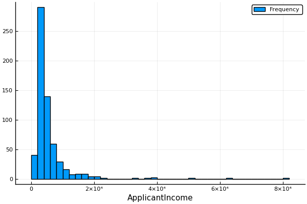

```julia
Plots.histogram(train[:, :ApplicantIncome],bins=50,xlabel="ApplicantIncome",labels="Frequency")
```

BoxPlot for Applicant Income by Education

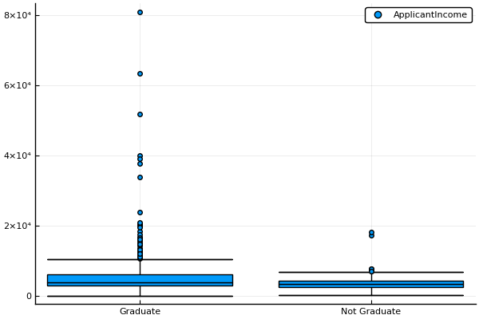

```julia
StatsPlots.boxplot(train[:, :Education],train[:, :ApplicantIncome],labels="ApplicantIncome")
```

We can also use plotly as a backend to make interactive plots

```julia
plotly()  #use plotly as backend
 Plots.histogram(train[:, :ApplicantIncome],bins=50,xlabel="ApplicantIncome",labels="Frequency")
```

[output not shown]

## Data Munging

We need to do the following steps to treat the data frame in preparation for modeling

1. Missing Value Imputation
2. Factor Variable Treatment

### Imputation

First Check to see which columns have missing values in them

```julia
describe(train)
```

[output not shown]

First, set up a duplicate dataframe for imputation

```julia
train2 = train;
```

Impute null and missing LoanAmount values to the column mean

```julia
train2[ismissing.(train2[:, :LoanAmount]), :LoanAmount] .= floor(mean(skipmissing(train2[:, :LoanAmount])));
```

```julia
train2[train2[:, :LoanAmount] .== 0, :LoanAmount] .= floor(mean(skipmissing(train2[:, :LoanAmount])));
```

Replace missing Gender values with the column mode

```julia
train2[ismissing.(train2[:, :Gender]), :Gender] .= mode(skipmissing(train2[:, :Gender]));
```

Replace missing Married values with the column mode

```julia
train2[ismissing.(train2[:, :Married]), :Married] .= mode(skipmissing(train2[:, :Married]));
```

Replace missing Dependents values with the column mode

```julia
train2[ismissing.(train2[:, :Dependents]), :Dependents] .= mode(skipmissing(train2[:, :Dependents]));
```

Replace missing Self Employed values with the column mode

```julia
train2[ismissing.(train2[:, :Self_Employed]), :Self_Employed] .= mode(skipmissing(train2[:, :Self_Employed]));
```

Replace missing Loan Amount Term with column mode

```julia
train2[ismissing.(train2[:, :Loan_Amount_Term]), :Loan_Amount_Term] .= mode(skipmissing(train2[:, :Loan_Amount_Term]));
```

```julia
train2[ismissing.(train2[:, :Credit_History]), :Credit_History] .= mode(skipmissing(train2[:, :Credit_History]));
```

Check to see if the missing values have been imputed

```julia
describe(train)
```

|  | variable Symbol | mean Union… | min Any | median Union… | max Any | nunique Union… | nmissing Union… |
| --- | --- | --- | --- | --- | --- | --- | --- |
| 1 | Loan_ID |  | LP001002 |  | LP002990 | 614 |  |
| 2 | Gender |  | Female |  | Male | 2 | 0 |
| 3 | Married |  | No |  | Yes | 2 | 0 |
| 4 | Dependents |  | 0 |  | 3+ | 4 | 0 |
| 5 | Education |  | Graduate |  | Not Graduate | 2 |  |
| 6 | Self_Employed |  | No |  | Yes | 2 | 0 |
| 7 | ApplicantIncome | 5403.46 | 150 | 3812.5 | 81000 |  |  |
| 8 | CoapplicantIncome | 1621.25 | 0.0 | 1188.5 | 41667.0 |  |  |
| 9 | LoanAmount | 146.397 | 9 | 129.0 | 700 |  | 0 |
| 10 | Loan_Amount_Term | 342.41 | 12 | 360.0 | 480 |  | 0 |
| 11 | Credit_History | 0.855049 | 0 | 1.0 | 1 |  | 0 |
| 12 | Property_Area |  | Rural |  | Urban | 3 |  |
| 13 | Loan_Status |  | N |  | Y | 2 |  |

So, we have succesfully imputed all the null values.